# First Model

## Project Setup

We chose to go with the ProjectTemplate package and structured our project accorgingly. With this setup, our data gets automatically loaded from the data directory and using the munge feature we also automatically build a **training set** and a **test set** by dividing the original dataset using a 70/30 ratio. To make sure that both the training and the test sets had a similar distribution, we have used the `sample.split()` function to have similar distributions over the **CreditLimit** variable, which we will perform predictions on.

We also set the seed to a fixed number so that we can produce the same sequence of random numbers between runs and our results are not effected by the changes in the datasets.

## Pre-Model Work

We developed our own functions to be able to calculate the errors for our models. These functions include **R-squared**, **Adjusted R-squared** and the **Root Mean Square Error (RMSE)**. We will make use of these functions for our initial model and the future models to track fitness of our models and the performance of our models comared to each other.

## Initial Model

We first wanted to find out if Sales would be a good indicator to predict Credit Limits for our customers. We chose the Last Year’s Sales (SalesLastYr) column and build a linear regression model with one independent variable. Our assumption is whether we can formulate the Credit Limit with a simple formula as the following:

$$Credit Limit = w*Previous Years Sales+b$$

```r
model <- lm(formula = CreditLimit ~ SalesLastYr,
            data = dataset_train)
```

```
##
## Call:
## lm(formula = CreditLimit ~ SalesLastYr, data = dataset_train)
##
## Residuals:
##    Min     1Q Median     3Q    Max
## -11949  -2283   -772   1578  41443
##
## Coefficients:
##              Estimate Std. Error t value Pr(>|t|)
## (Intercept) 3.179e+03  1.278e+02  24.870  < 2e-16 ***
## SalesLastYr 3.213e-02  4.748e-03   6.766 1.93e-11 ***
## ---
## Signif. codes:  0 '***' 0.001 '**' 0.01 '*' 0.05 '.' 0.1 ' ' 1
##
## Residual standard error: 4315 on 1430 degrees of freedom
## Multiple R-squared:  0.03102,    Adjusted R-squared:  0.03034
## F-statistic: 45.78 on 1 and 1430 DF,  p-value: 1.928e-11
```

The `summary()` results of this model trained using the **training set** shows that both the intercept (b) and the coefficient (w) are significant (P values are much less than 0.05). This might be a good start but how good of a fit is this model to our data?

R-squared paramater indicats the the fitness of a model and we want this value to be closer to 1, aka we want the ratio of the sum of the square of the residuals ($SS_r$) over the sum of the square of the averages ($SS_t$) to be small so that $R^2$ becomes larger.

$$R^2 = 1 - SS_r/SS_t$$

The value 0.03102 for the $R^2$ seemed low which is indicating that the model is not a good fit. And at this time we are not concerned with the Adjusted $R^2$ since we have only one independent variable in our model.

The three of the indicators that we are planning on using for this model and the next models that we are planning on building are; $R^2$, Adjusted $R^2$ and the RMSE and here is a recap of these three indicators for our training model:

```
## R Squared:  0.03101796
```

```
## R Squared (Adjusted):  0.03034035
```

```
## Root Mean Square Error:  4312.198
```

And below are the results of the same three indicators for our test set:

```
## R Squared:  0.07942551
```

```
## R Squared (Adjusted):  0.07791884
```

```
## Root Mean Square Error:  4106.185
```

The $R^2$ value is slightly better for the test set than the training set but in both cases these values still indicate not a good fit. The RSME values for both the raining and the test sets seems to be close to each other and we hope to see this number go lower as we build better models.

## Data Insights

We have performed other exploratory analysis on our data and we began our examination with the **Sales** numbers for the **Last Calender Year**. We looked at the min, max, std dev and the quintiles to understand the data better as well as to be able to do a comparison between the training and the test sets.

#### Training Set Summary

```
##    Min. 1st Qu.  Median    Mean 3rd Qu.    Max.
##       0    2236    5256   12154   12619  428636
```

```
## Std Dev. 24024.24
```

#### Test Set Summary

```
##    Min. 1st Qu.  Median    Mean 3rd Qu.    Max.
##   -2227    1961    5206   11486   12215  353229
```

```
## Std Dev. 21839.5
```

Both in the training set and the test set these numbers seemed to be close to each other and we do notice that the Sales numbers are clustred more towards the left of the scale. To visulaize this better we have created a distogram of the sales numbers for the traning set and the test set so that we can do a visual side by side analysis.

#### Comparison of Distribution of Sales Between the Training Set and the Test Set

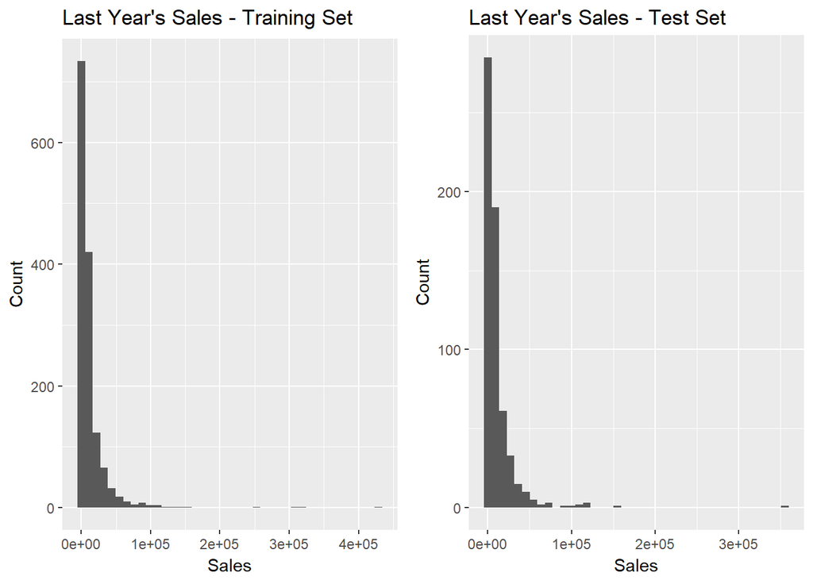

Upon visual inspection of the **Sales** data between the training and the test sets, we do see that they are distributed similarly.

We also wanted to see how the distrubution of Last Year’s Sales looked like compared to the distribution of Credit Limits for the same data points.

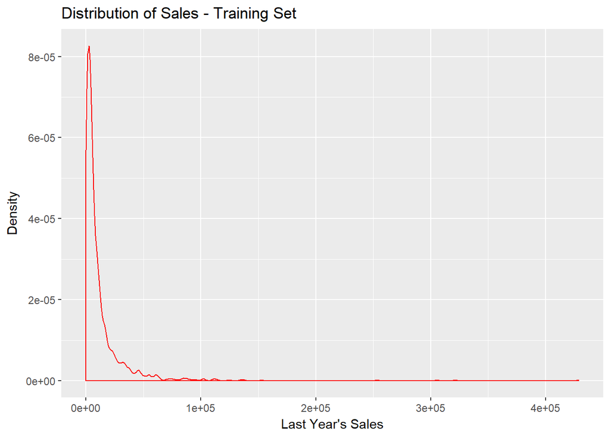

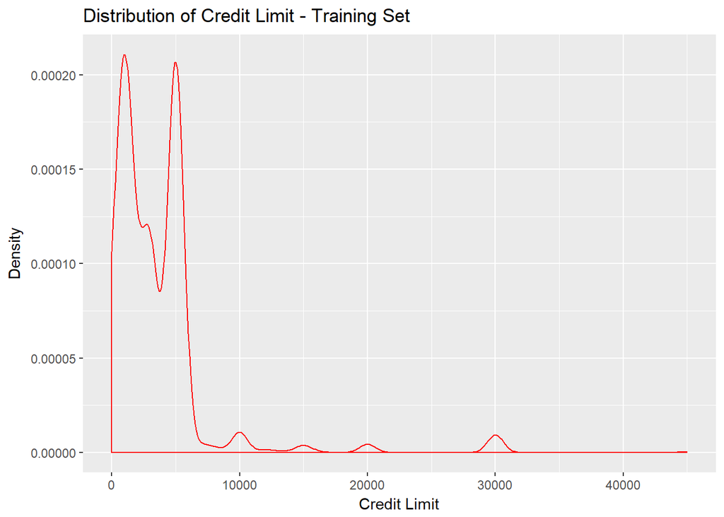

## Performance of the Model

To understand the correlation between these two variables and how our model repsresents this data, we have plotted the **Credit Limit vs. Last Year’s Sales** and also plotted a line representing our model.

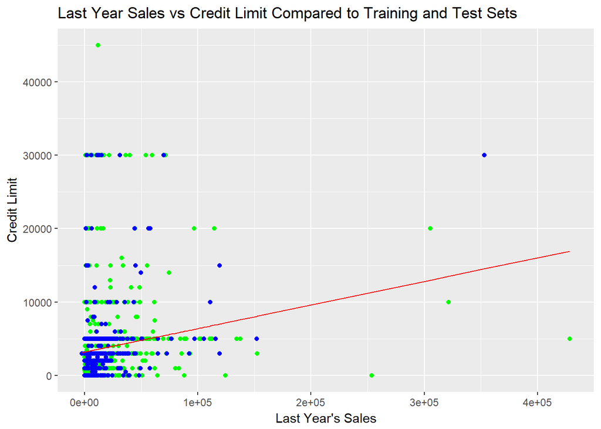

It is possible that the Credit Limit cannot be explained by one varaible and a linear relationship might still exist using other independent variables. It is also possible that the relationships are non-linear and we might have to build non-linear models to explain the data.

## Next Step

We will try to improve our linear model by examining all other variables that we have in our dataset and use a **Backward Elimitaion** to find out the most significant variables which might help us to build a better model. As we add more variables to describe our model we will also utilize the Adjusted $R^2$ predictor to account for the impact of the added variables tot he $R^2$ value.

Future steps might also include adding non-linear terms to the model or building other non-linear models such as **Decision Tree** or take advantage of ensemble learning by building a model usning **Random Forest**.